# Report of potential non HSCs

## Summary of excluded HSC

After taking a further look to tiff images, we incorporated 12 more cells as hematopoietic stem cells, leaving us with an exclusion of **12 out of 84 HSCs**. Please find attached the table of excluded HSCs.

```python
import pandas as pd
df = pd.ExcelFile("C:/Users/cdedi/Desktop/excluded_hsc.xlsx")
df = df.parse("Hoja1")
df.style.hide_index()
```

| Status | Sample | Reference | PositionX | PositionY | PositionZ | Veredict |
| --- | --- | --- | --- | --- | --- | --- |
| Aged | Femur 4 | Points 2 | 244 | 221 | 7 | 2 to 1 |
| Aged | Femur 8 | Points 1 | 75 | 162 | 10 | 2 to 1 (also because proximal to vasculature) |
| Aged | Femur 8 | Points 5 | 254 | 139 | 7 | 1 (covered by diff cells) |
| Aged | Femur 8 | Points 6 | 395 | 216 | 7 | 1 (covered by diff cells) |
| Aged | Femur 8 | Points 12 | 777 | 691 | 3 | 0 (white remarkable signal) |
| Aged | Humerus 1 | Points 13 | 241 | 732 | 6 | 1 |
| Aged | Humerus 1 | Points 15 | 395 | 898 | 4 | 2 to 1 |
| Aged | Humerus 6 | Points 9 | 451 | 487 | 3 | 0 |
| Aged | Humerus 6 | Points 10 | 394 | 753 | 3 | 1 |
| Aged | Humerus 6 | Points 13 | 381 | 894 | 0 | 1 |
| Young | Humerus 4 | Points 1 | 527 | 663 | 0 | 0 |
| Young | Humerus 4 | Points 2 | 352 | 689 | 1 | 1 |

```python
import pandas as pd
df = pd.ExcelFile("C:/Users/cdedi/Desktop/excluded_hsc.xlsx")
df = df.parse("Hoja2")
df.style.hide_index()
```

| Status | Sample | Reference | White signal | Blue signal | Spherical | Veredict |
| --- | --- | --- | --- | --- | --- | --- |
| Aged | Femur 4 | Points 2 | Background | Slight | Yes, but only two slices | 2 to 1 |
| Aged | Femur 8 | Points 1 | Slight but different from background | Medium | Probably (only half of the cell in the sample) | 2 to 1 (also because proximal to vasculature) |
| Aged | Femur 8 | Points 5 | Medium to strong | Slight | Not so much | 1 (covered by diff cells) |
| Aged | Femur 8 | Points 6 | Medium to strong | Very slight | Yes? Two slices, weird morphology | 1 (covered by diff cells) |
| Aged | Femur 8 | Points 12 | Strong (a really strong point) | No signal | Yes | 0 (white remarkable signal) |
| Aged | Humerus 1 | Points 13 | Slight and little overlapping | Slight | Yes | 1 |
| Aged | Humerus 1 | Points 15 | Medium | Slight | Yes | 2 to 1 |
| Aged | Humerus 6 | Points 9 | Surrounding | Strong | Yes? | 0 |
| Aged | Humerus 6 | Points 10 | Medium to strong | Medium | Yes | 1 |
| Aged | Humerus 6 | Points 13 | Slight but overlapping with differentiated cells (segmentable?) | Medium | Probably (only half of the cell in the sample) | 1 |
| Young | Humerus 4 | Points 1 | Slight with overlapping dif cells | Strong | Probably (only half of the cell in the sample) | 0 |
| Young | Humerus 4 | Points 2 | Slight with overlapping cells | Slight | Yes (but very weird morphology) | 1 |

## Visualization: the function

Taking this into consideration, to ease the visualization and analysis of the excluded HSC, we decided to create a function to analyze and show each channel from each HSC. Please find attached the function below:

```python
# Importing libraries
import cv2
import matplotlib.pyplot as plt
# Being imgroute the folder were the images are; z, xpos and ypos the coordinates of the cell; and surrpix the pixels to create the rectangle of the images (considering xpos and ypos = 0)
def cell_analyzer(imgroute, z, xpos, ypos,surrpix):
    # Image load
    if z < 10:
        red = cv2.imread(imgroute + "/T00001C01Z00" + str(z+1) + ".tif",0)
        white = cv2.imread(imgroute + "/T00001C02Z00" + str(z+1) + ".tif",0)
        blue = cv2.imread(imgroute + "/T00001C03Z00" + str(z+1) + ".tif",0)
    else:
        red = cv2.imread(imgroute + "/T00001C01Z0" + str(z+1) + ".tif",0)
        white = cv2.imread(imgroute + "/T00001C02Z0" + str(z+1) + ".tif",0)
        blue = cv2.imread(imgroute + "/T00001C03Z0" + str(z+1) + ".tif",0)
    # Channel plotting
    plt.figure(figsize = (20,20))
    plt.subplot(1,3,1),plt.imshow(red[(ypos-surrpix):(ypos+surrpix),(xpos-surrpix):(xpos+surrpix)],cmap="hot")
    plt.title("Red channel")
    plt.subplot(1,3,2),plt.imshow(white[(ypos-surrpix):(ypos+surrpix),(xpos-surrpix):(xpos+surrpix)],cmap="gray")
    plt.title("White channel")
    plt.subplot(1,3,3),plt.imshow(blue[(ypos-surrpix):(ypos+surrpix),(xpos-surrpix):(xpos+surrpix)],cmap="Blues")
    plt.title("Blue channel")
```

## Visualization: results

All things considered, we show the three channels for each cell, as well as a little commentary about the cause of exclusion

### Aged Femur 4, Points 2

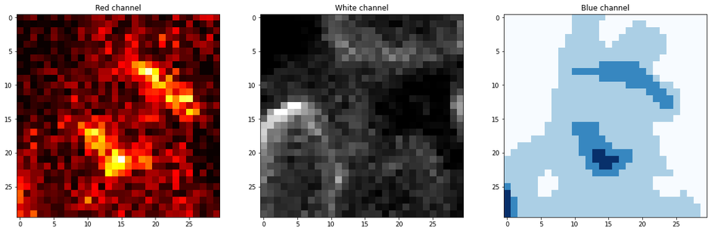

```python
cell_analyzer("C:/Users/cdedi/Desktop/Master images/aged/Femur 4", 7, 244, 221, 15)
```

**Comment:** This HSC was basically excluded because I only saw the cell represented in two slices and because of the overlapping white signal

### Aged Femur 8, Points 1

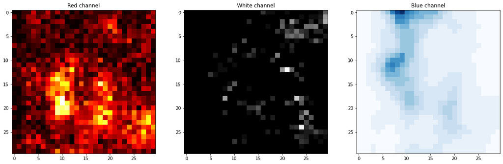

```python
cell_analyzer("C:/Users/cdedi/Desktop/Master images/aged/Femur 8", 10, 75, 162, 15)
```

**Comment:** White signal is different from background. Blue signal is medium

### Aged Femur 8, Points 5

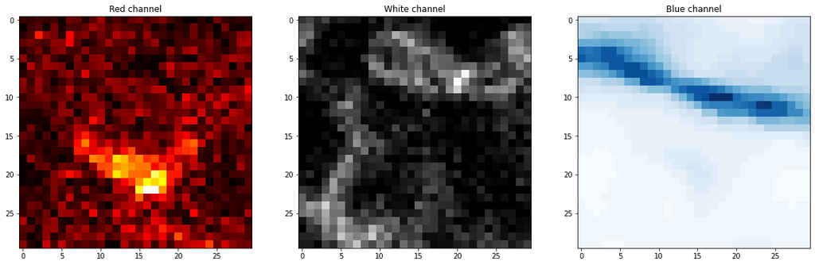

```python
cell_analyzer("C:/Users/cdedi/Desktop/Master images/aged/Femur 8", 7, 254, 139, 15)
```

**Comment:** This one was not spherical, and the cell is covered by differentiated cells

### Aged Femur 8, Points 6

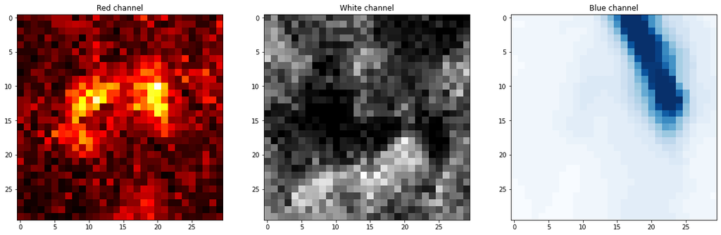

```python
cell_analyzer("C:/Users/cdedi/Desktop/Master images/aged/Femur 8", 7, 395, 216, 15)
```

**Comment:** The cell is covered by differentiated cells

### Aged Femur 8, Points 12

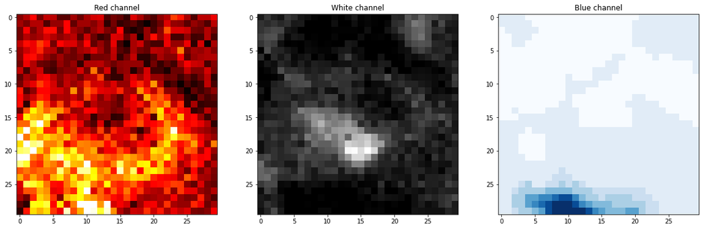

```python
cell_analyzer("C:/Users/cdedi/Desktop/Master images/aged/Femur 8", 3, 777, 691,15)
```

**Comment:** White signal is really intense

### Aged Humerus 1, Points 13

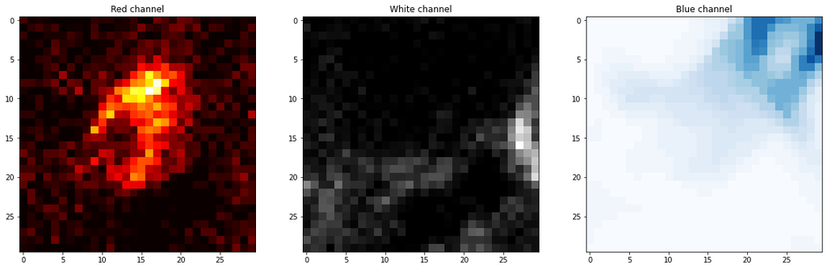

```python
cell_analyzer("C:/Users/cdedi/Desktop/Master images/aged/Humerus 1", 6, 241, 732,15)
```

### Aged Humerus 1, Points 15

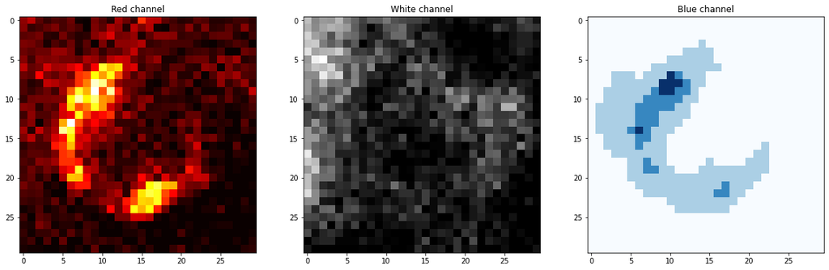

```python
cell_analyzer("C:/Users/cdedi/Desktop/Master images/aged/Humerus 1", 4, 395, 898,15)
```

### Aged Humerus 6, Points 9

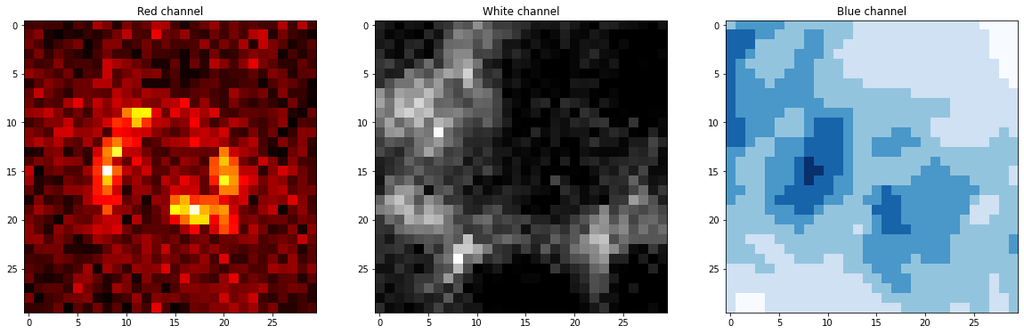

```python
cell_analyzer("C:/Users/cdedi/Desktop/Master images/aged/Humerus 6", 3,451,487,15)
```

**Comment:** This HSC seems to have many cells surrounding and it will be diffuse and maybe a little bit overlapping. Blue signal is also significant.

### Aged Humerus 6, Points 10

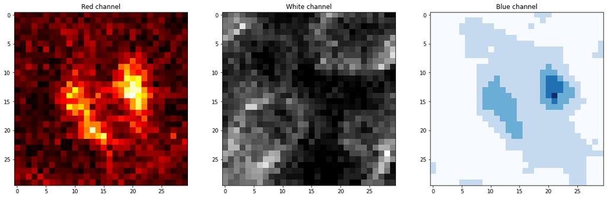

```python
cell_analyzer("C:/Users/cdedi/Desktop/Master images/aged/Humerus 6", 3, 394, 753, 15)
```

**Comment:** White and blue signal seem to have medium to strong intensities. Differentiated cells seem to be overlapping

### Aged Humerus 6, Points 13

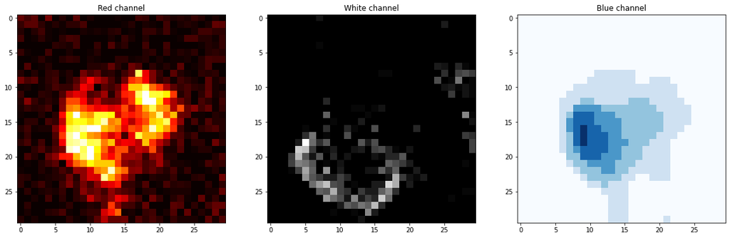

```python
cell_analyzer("C:/Users/cdedi/Desktop/Master images/aged/Humerus 6", 0, 381, 894, 15)
```

**Comment:** It kind of overlaps with a differentiated cell, and blue signal is significant

### Young Humerus 4, Points 1

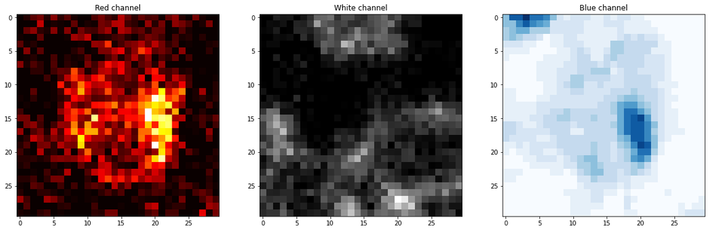

```python
cell_analyzer("C:/Users/cdedi/Desktop/Master images/young/Humerus 4", 0, 527, 663, 15)
```

**Comment:** White and blue signals are significant enough to doubt

### Young Humerus 4, Points 2

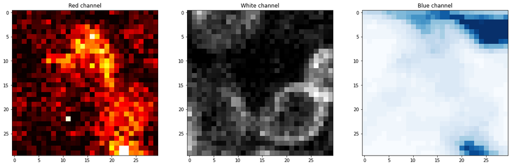

```python
cell_analyzer("C:/Users/cdedi/Desktop/Master images/young/Humerus 4", 1, 352, 689, 15)
```

**Comments:** So many differentiated cells overlapping and morphology is not clear